Create some simulated data and fit simple linear regression models to it.

```r
set.seed(1)
```

## a. b. c. Using rnorm() create a vector x with 100 obs from N(mean = 0, sd = 1). This represents a feature X.

```r
x = rnorm(100, mean=0, sd=1) # mean 0 and sd 1 is the default
eps = rnorm(100, mean=0, sd=0.25^0.5) # var 0.25 => sd sqrt(0.25)
y = -1 + 0.5 * x + eps
```

- What is the length of the vector `y`? 100
- What are the values of `B_0` and `B_1` in this linear model? -1, 0.5

## d. Create a scatterplot displaying the relationship between `x` and `y`. Comment.

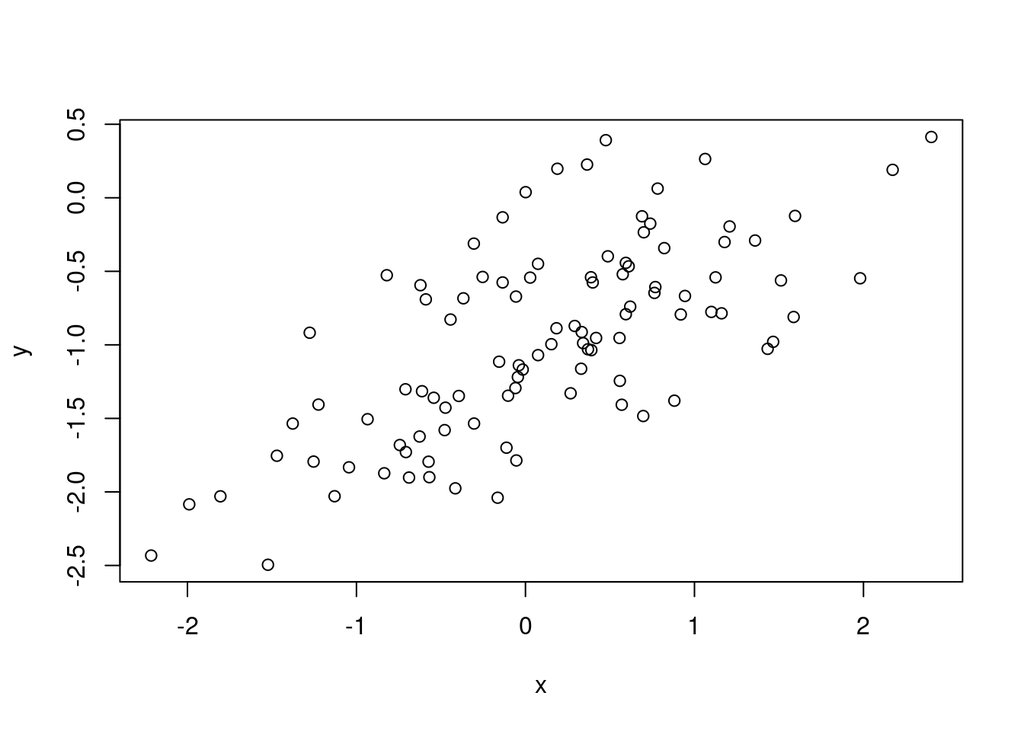

```r
plot(x, y)
```

## e. Fit a least squares model to predict y given x.

```r
lm.y_fit = lm(y~x)
summary(lm.y_fit)
```

```
##
## Call:
## lm(formula = y ~ x)
##
## Residuals:
##      Min       1Q   Median       3Q      Max
## -0.93842 -0.30688 -0.06975  0.26970  1.17309
##
## Coefficients:
##             Estimate Std. Error t value Pr(>|t|)
## (Intercept) -1.01885    0.04849 -21.010  < 2e-16 ***
## x            0.49947    0.05386   9.273 4.58e-15 ***
## ---
## Signif. codes:  0 '***' 0.001 '**' 0.01 '*' 0.05 '.' 0.1 ' ' 1
##
## Residual standard error: 0.4814 on 98 degrees of freedom
## Multiple R-squared:  0.4674, Adjusted R-squared:  0.4619
## F-statistic: 85.99 on 1 and 98 DF,  p-value: 4.583e-15
```

- How do the estimated `Bs` compare to the actual `Bs`

They’re very close because the true distribution is normal.

## f. Display the least squares line on the scatterplot from d.

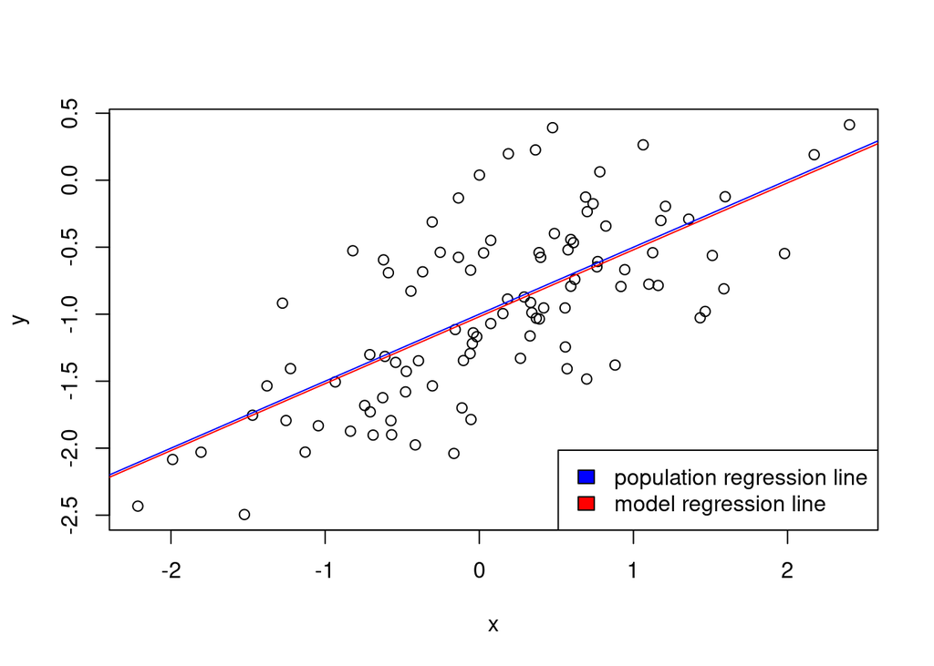

```r
plot(x, y)
abline(lm.y_fit, col="red")
abline(-1, 0.5, col="blue")
legend(x="bottomright", legend=c("population regression line", "model regression line"), fill=c("blue", "red"))
```

NB: `abline` takes the intercept and slope of the line which is stored in lm.y_fit, and an argument to denote color, stored as a string.

```r
lm.y_fit
```

```
##
## Call:
## lm(formula = y ~ x)
##
## Coefficients:
## (Intercept)            x
##     -1.0188       0.4995
```

- Draw the population regression line on the plot, in a different color.

The population regression line will be an `abline` with the actual intercept and slope from the equation, not the estimated ones.

- Use the `legend()` command to creaet an appropriate legend

Note that `legend` requires at least 3 arguments to make sense. An `x` (which could be a combined x,y conveyed via a string value), the `legend` variable itself, and the colors used in the `abline` corresponding to the labels specified in the `legend` variable.